# VW

# EDA

```r
# pacotes necessarios

library(tidyverse)
theme_set(theme_bw())
library(GGally)
# leitura dos dados

vw <- read_csv(file = "dados/vw.csv")
```

Como em toda análise de dados, a primeira tarefa a ser realizada é a sua análise exploratória. Neste caso, quero verificar como está a relação entre as variáveis neste conjunto de dados, excetuando o modelo. Vou deixar esta variável de fora por enquanto, pois ela possui muitos níveis diferentes. Além disso, reordenei as colunas de modo que `price` fosse a primeira e, assim, a interpretação dos resultados ficasse mais simples. Note que, além disso, calculei a correlação de Spearman entre as variáveis, pois graficamente elas não apresentam linearidade ou normalidade.

[output not shown]

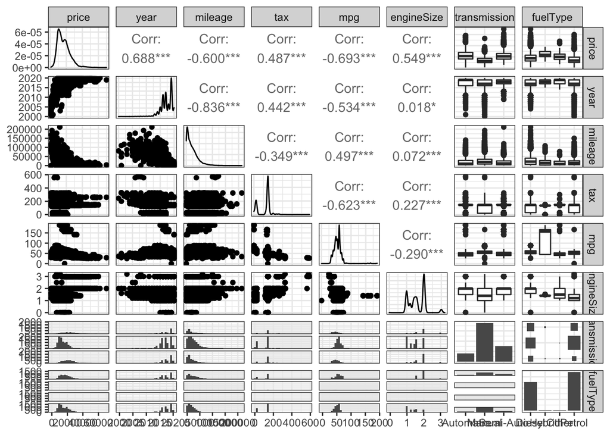

```r
vw %>%
  select(-model) %>%
  relocate(price) %>%
  relocate(where(is.character), .after = last_col()) %>%
  ggpairs(upper = list(continuous = wrap("cor", method = "spearman")))
```

Este gráfico nos dá uma ideia de como o preço está correlacionado com as outras variáveis preditoras. A maior correlação positiva do preço ocorre em relação ao ano de fabricação do veículo. Quanto mais recente o carro, maior o seu preço. O mesmo vale para o imposto (`tax`) e tamanho do motor (`engineSize`). Intuitivamente, nenhuma destas relações me parece estar longe do esperado.

O preço está correlacionado negativamente em relação à milhagem (`mileage`) e consumo de combustível (`mpg`, sigla para *miles per galon*). Novamente, de forma intuitiva, estes resultados prévios parecem estar condizentes com o esperado para dados assim.

A relação do preço com as variáveis qualitativas não está muito clara. A diferença de nível parece pequena e com muitos outliers. Entretanto, devido ao grande volume de dados (15157 observações), é possível que as diferenças de nível vistas nos boxplots sejam significativas.

## Preparação dos Dados

Antes de partir para a modelagem em si, é necessário que os dados sejam preparados. Neste caso, a minha modelagem inicial vai contar com três etapas:

1. Limpeza dos Dados
2. Divisão dos Dados em Treinamento e Teste
3. Pré-Processamento das Variáveis Preditoras

### Limpeza dos Dados

Como é possível ver nos gráficos criados pela nossa análise exploratória, há uma quantidade maior de carros fabricados nos últimos 5 anos do que nos anos menos recentes. Abaixo veremos o quão grande é esta disparidade:

```r
vw %>%
  group_by(year) %>%
  count() %>%
  ungroup() %>%
  arrange(desc(year)) %>%
  mutate(percentual = n/sum(n)*100,
         acumulado = cumsum(percentual)) %>%
  print(n = Inf)
```

```
## # A tibble: 21 × 4
##     year     n percentual acumulado
##    <dbl> <int>      <dbl>     <dbl>
##  1  2020  1046    6.90         6.90
##  2  2019  4669   30.8         37.7
##  3  2018  1509    9.96        47.7
##  4  2017  2947   19.4         67.1
##  5  2016  2647   17.5         84.6
##  6  2015  1153    7.61        92.2
##  7  2014   580    3.83        96.0
##  8  2013   315    2.08        98.1
##  9  2012    80    0.528       98.6
## 10  2011    57    0.376       99.0
## 11  2010    41    0.271       99.3
## 12  2009    31    0.205       99.5
## 13  2008    27    0.178       99.6
## 14  2007    20    0.132       99.8
## 15  2006    16    0.106       99.9
## 16  2005     8    0.0528      99.9
## 17  2004     3    0.0198      99.9
## 18  2003     2    0.0132     100.
## 19  2002     1    0.00660    100.
## 20  2001     4    0.0264     100.
## 21  2000     1    0.00660    100
```

Como é possível ver, 92,2% dos carros foram fabricados de 2015 em diante. Ou seja, manter carros mais antigos do que esta data no conjunto de dados vai causar um desbalanceamento muito grande, prejudicandos os resultados. Além disso, se criarmos uma tabela que conte o número de modelos de carro por ano, a situação fica bem complicada:

```r
vw %>%
  select(year, model) %>%
  group_by(year, model) %>%
  count() %>%
  ungroup() %>%
  complete(year, model, fill = list(n = 0)) %>%
  pivot_wider(names_from = "year", values_from = "n") %>%
  rmarkdown::paged_table()
```

| model | 2000 | 2001 | 2002 | 2003 | 2004 | 2005 | 2006 | 2007 | 2008 | 2009 | 2010 | 2011 | 2012 | 2013 | 2014 | 2015 | 2016 | 2017 | 2018 | 2019 | 2020 |
| --- | --- | --- | --- | --- | --- | --- | --- | --- | --- | --- | --- | --- | --- | --- | --- | --- | --- | --- | --- | --- | --- |
| Amarok | 0 | 0 | 0 | 0 | 0 | 0 | 0 | 0 | 0 | 0 | 0 | 0 | 0 | 1 | 3 | 13 | 7 | 11 | 21 | 49 | 6 |
| Arteon | 0 | 0 | 0 | 0 | 0 | 0 | 0 | 0 | 0 | 0 | 0 | 0 | 0 | 0 | 0 | 0 | 0 | 11 | 38 | 183 | 16 |
| Beetle | 0 | 3 | 0 | 1 | 0 | 1 | 3 | 3 | 0 | 1 | 0 | 0 | 1 | 6 | 17 | 15 | 21 | 7 | 4 | 0 | 0 |
| Caddy | 0 | 0 | 0 | 0 | 0 | 0 | 0 | 0 | 0 | 0 | 0 | 0 | 1 | 0 | 0 | 2 | 2 | 1 | 0 | 0 | 0 |
| Caddy Life | 0 | 0 | 0 | 0 | 0 | 0 | 0 | 0 | 0 | 0 | 0 | 0 | 0 | 1 | 0 | 0 | 0 | 3 | 0 | 2 | 2 |
| Caddy Maxi | 0 | 0 | 0 | 0 | 0 | 0 | 0 | 0 | 0 | 0 | 0 | 0 | 1 | 0 | 0 | 2 | 0 | 1 | 0 | 0 | 0 |
| Caddy Maxi Life | 0 | 0 | 0 | 0 | 0 | 0 | 0 | 0 | 0 | 0 | 0 | 0 | 0 | 0 | 2 | 0 | 2 | 4 | 8 | 36 | 7 |
| California | 0 | 0 | 0 | 0 | 0 | 0 | 0 | 0 | 0 | 0 | 0 | 0 | 0 | 0 | 0 | 0 | 0 | 0 | 1 | 13 | 1 |
| Caravelle | 0 | 0 | 0 | 0 | 0 | 1 | 2 | 0 | 0 | 0 | 0 | 4 | 5 | 4 | 1 | 4 | 2 | 0 | 1 | 66 | 11 |
| CC | 0 | 0 | 0 | 0 | 0 | 0 | 0 | 0 | 0 | 0 | 0 | 1 | 4 | 16 | 16 | 23 | 31 | 4 | 0 | 0 | 0 |

[output cut: 17 more lines]

Há uma quantidade de zeros muito grande na tabela construída. Graficamente, a situação é bastante clara:

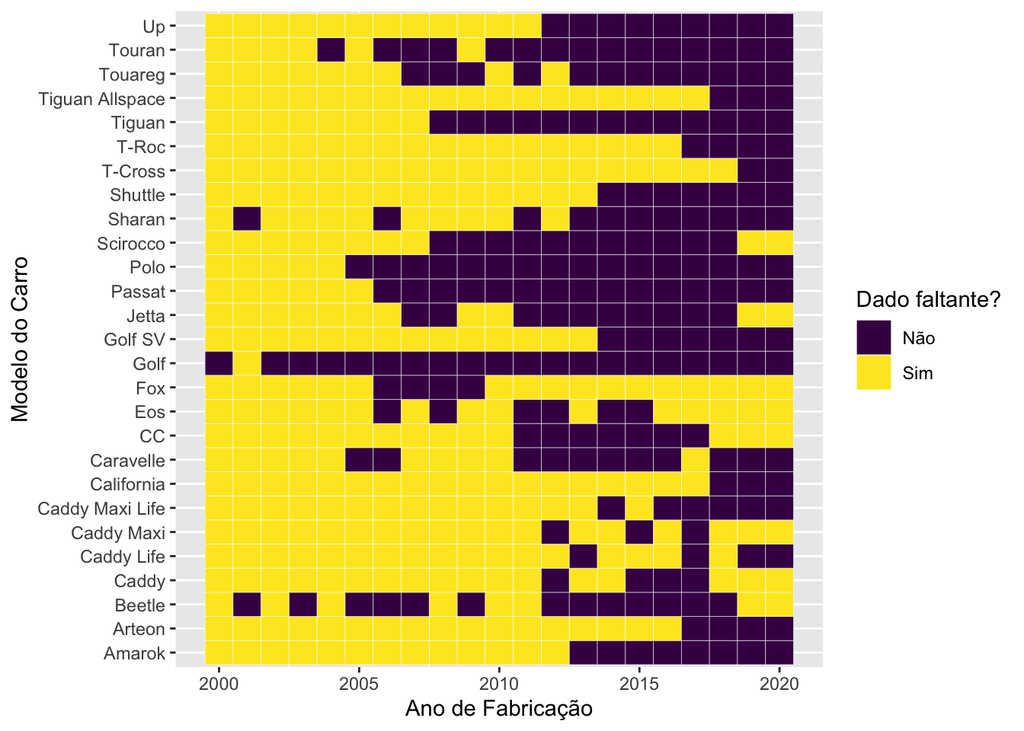

```r
vw %>%
  select(year, model) %>%
  group_by(year, model) %>%
  count() %>%
  ungroup() %>%
  complete(year, model, fill = list(n = 0)) %>%
  mutate(faltante = ifelse(n == 0, "Sim", "Não")) %>%
  ggplot(., aes(x = year, y = model, fill = faltante)) +
  geom_tile(colour = "white") +
  labs(x = "Ano de Fabricação",
       y = "Modelo do Carro",
       fill = "Dado faltante?") +
  scale_fill_viridis_d()
```

A grande quantidade de retângulos amarelos no gráfico acima mostra como há muitos dados faltantes. Em particular, 59,79% das combinações entre modelo de carro e ano não possuem nenhuma ocorrência. Por isso, baseado no fato de que 92,2% dos carros foram fabricados de 2015 em diante, vou restringir arbitrariamente este conjunto de dados para apenas os anos mais recentes, a partir desta data. Com isso, temos o seguinte:

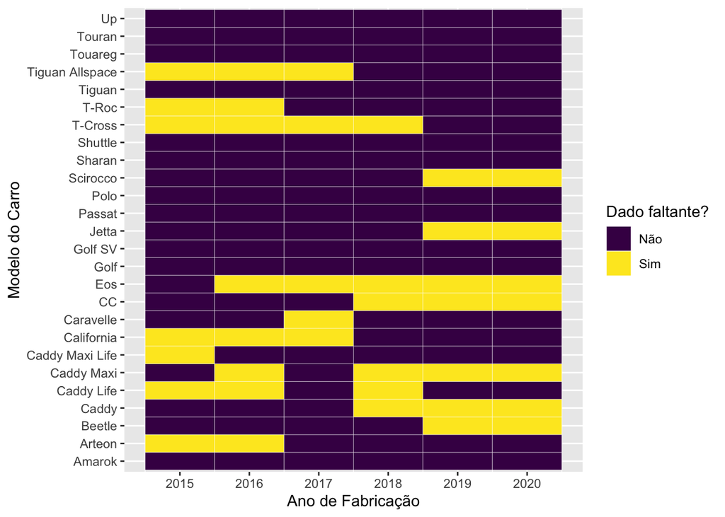

```r
vw_bk <- vw

vw <-
  vw_bk %>%
  filter(year >= 2015)

vw %>%
  select(year, model) %>%
  group_by(year, model) %>%
  count() %>%
  ungroup() %>%
  complete(year, model, fill = list(n = 0)) %>%
  mutate(faltante = ifelse(n == 0, "Sim", "Não")) %>%
  ggplot(., aes(x = year, y = model, fill = faltante)) +
  geom_tile(colour = "white") +
  scale_x_continuous(breaks = seq(2015, 2020), labels = seq(2015, 2020)) +
  labs(x = "Ano de Fabricação",
       y = "Modelo do Carro",
       fill = "Dado faltante?") +
  scale_fill_viridis_d()
```

Com isso, apenas 25,64% das combinações estão faltando. Ainda assim, modelos como Eos, Caddy Maxi e Caddy Life parecem ter um comportamento não ideal, ainda com dados faltantes para muitos anos. Por isso, vou retirar todas as ocorrências deles do banco de dados.

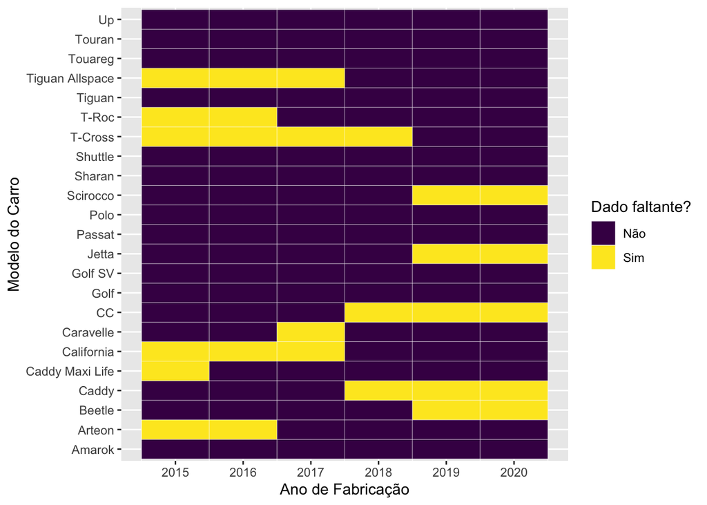

```r
vw <-
  vw %>%
  filter(model != "Eos" & model != "Caddy Maxi" & model != "Caddy Life")

vw %>%
  select(year, model) %>%
  group_by(year, model) %>%
  count() %>%
  ungroup() %>%
  complete(year, model, fill = list(n = 0)) %>%
  mutate(faltante = ifelse(n == 0, "Sim", "Não")) %>%
  ggplot(., aes(x = year, y = model, fill = faltante)) +
  geom_tile(colour = "white") +
  scale_x_continuous(breaks = seq(2015, 2020), labels = seq(2015, 2020)) +
  labs(x = "Ano de Fabricação",
       y = "Modelo do Carro",
       fill = "Dado faltante?") +
  scale_fill_viridis_d()
```

Agora sim, com apenas 20,29% de combinações entre anos e modelos de carros faltantes, podemos proceder com a análise. Além disso, continuamos com 13960 linhas no conjunto de dados a ser analisado, uma perda de apenas 7.9% em relação às 15157 linhas do conjunto de dados original.

### Divisão dos Dados em Treinamento e Teste

Um post antigo deste blog, intitulado [Tutorial: Como Fazer o Seu Primeiro Projeto de Data Science](https://marcusnunes.me/posts/primeiro-projeto-de-data-science/), discute a razão do porquê dividirmos os dados em treino e teste. Por este motivo, não irei justificar novamente a razão de termos que fazer algo nesta linha.

A partir de agora, utilizaremos o pacote `tidymodels` para tratar os dados antes das análises preditivas. Vamos dividir os dados em 75% para o treinamento e 25% para o teste.

```r
# pacote necessario

library(tidymodels)
# 75% dos dados como treino

set.seed(2410)

vw_split <- initial_split(vw, prop = .75)

# criar os conjuntos de dados de treino e teste

vw_treino <- training(vw_split)
vw_teste  <- testing(vw_split)
```

### Pré-Processamento das Variáveis Preditoras

O segundo passo é centrar e escalar as variáveis preditoras. Isto é, deixá-las todas com média 0 e desvio padrão 1. Este passo ajuda na convergência dos algoritmos que utilizaremos para nossa modelagem.

Ao final, teremos um objeto chamado `vw_rec`, que lembrará quais são os passos que utilizamos para preparar os dados para análise, de modo que as mesmas transformações possam ser aplicadas tanto no conjunto de treino quanto no conjunto de teste.

```r
vw_rec <-
  # regressao que serah aplicada aos dados
  recipe(price ~ .,
         data = vw_treino) %>%
  # criacao das variaveis dummy
  step_dummy(where(is.character)) %>%
  # center/scale
  step_center(where(is.numeric), -price) %>%
  step_scale(where(is.numeric), -price) %>%
  # funcao para aplicar a transformacao aos dados
  prep()
```

Em seguida, a receita `vw_rec` é aplicada aos conjuntos de treino e teste.

```r
# aplicar a transformacao aos dados

vw_treino_t <- juice(vw_rec)

# preparar o conjunto de teste

vw_teste_t <- bake(vw_rec,
                   new_data = vw_teste)
```

Com os dados preparados, é hora de partirmos para a modelagem propriamente dita.

# Modelagem

O objetivo a partir de agora é prever o preço do carro em função as outras variáveis. Duas abordagens serão utilizadas e comparadas. A primeira delas é a regressão linear. Em seguida, vou utilizar random forests. Para que ambas sejam comparáveis, vou utilizar o pacote `tidymodels`, de modo que as métricas sejam as mesmas para ambas as abordagens.